# Unit 12 Case Study - Simulation Study of a Branching Process

Zach Brown

July 26, 2017

# Introduction

Branching processes consist of some sort of parent process (e.g. a computer processor thread) that can spawn child processes. The child processes can also spawn child processes which can also spawn child processes and so on. Each process has a creation time (or birth time) when it begins running. Each process also has a completion time (or death time) when it finishes running.

Random branching processes can be simulated fairly easily, given some parameters. The first parameter is the rate of process creation or lambda. The second parameter is the rate of process completion or kappa. The lifecycle of a random process can be modeled using a Poisson distribution with these two rates. One potential issue with simulations of random branching processes is that they can spawn for an infinite number of generations. In order to combat this and produce a complete family tree, constraints can be put on several parameters. The simplest method is to set a hard cap on the number of generations. Another option is to limit the maximum running time of the entire branching process tree. For the purposes of this case study, we will use the first method.

When analyzing a branching process it can be helpful to use graphical plots. Being able to visually inspect the aspects of a family tree can present insights into the data that may be otherwise overlooked. In Chapter 7 of “Data Science in R: A Case Studies Approach to Computational Reasoning and Problem Solving” by Nolan and Lang, a custom graph is created to visualize a family tree. The objective of this case study is to modify that custom graph as detailed in exercise 6 of the same chapter.

# Methods and Results

The first step to modeling a branching process is to create a function that generates child processes given a parent process. We will denote birth time, completion time, ID of the parent process, rate for the inter-arrival of offspring, and a rate for the run times of the offspring with the parameters bTimes, cTimes, lambda, and kappa respectively.

```r
genKidsV = function(bTimes, cTimes, parentID, lambda = 0.5, kappa = 0.3) {
       # Determine how many children each job has
  parentAge = cTimes - bTimes
  numKids = rpois(n = length(parentAge), lambda = lambda * parentAge)

  if (sum(numKids) == 0) return(NULL)

       # Determine the birth times of the children
  kidStats =
    mapply(function(n, min, max) {
      births = sort(runif(n, min, max))
      runtimes = rexp(n, rate = kappa)
      completes = rep(max, n) + runtimes
      data.frame(births, completes)
    },
           n = numKids , min = bTimes, max = cTimes,
           SIMPLIFY = FALSE)


  return(data.frame(parentID = rep(parentID, numKids),
                    kidID = 1:sum(numKids),
                    births = unlist(lapply(kidStats, "[[", "births")),
                    completes = unlist(lapply(kidStats,"[[", "completes"))
                    ))
}
```

Now that we can create a generation using the genKidsV function, we can use this to model the entire process. To guard against the process running for an infinite number of generations, we will pass a parameter to this new function to set the maximum number of generations to be modeled.

```r
familyTree = function(lambda = 0.5, kappa = 0.3, maxGen = 10) {
  # maxGen - maximum number of generations to observe
  # Return value - a list with 1 data frame per generation.
  allGens = vector(mode = "list", length = maxGen)

  # Generate the root of the tree
  allGens[[1]] = data.frame(parentID = NA, kidID = 1, births = 0,
                            completes = rexp(1, rate = kappa))

  # Generate future generations, one at a time.
  for (i in 2:maxGen) {
    nextGen = genKidsV(bTimes = allGens[[ (i - 1) ]]$births,
                       cTimes = allGens[[ (i - 1) ]]$completes,
                       parentID = allGens[[ (i - 1) ]]$kidID,
                       lambda = lambda, kappa = kappa)
    if (is.null(nextGen)) return(allGens[ 1:(i - 1) ])
    allGens[[ i ]] = nextGen
  }

  return(allGens)
}
```

Now we can test this function

```r
seed1 = 12062013
set.seed(seed1)
tree = familyTree(lambda = 0.4, kappa = 1, maxGen = 10)
```

Since there is so much data generated by the familyTree function, it is easier to investigate it by plotting it.

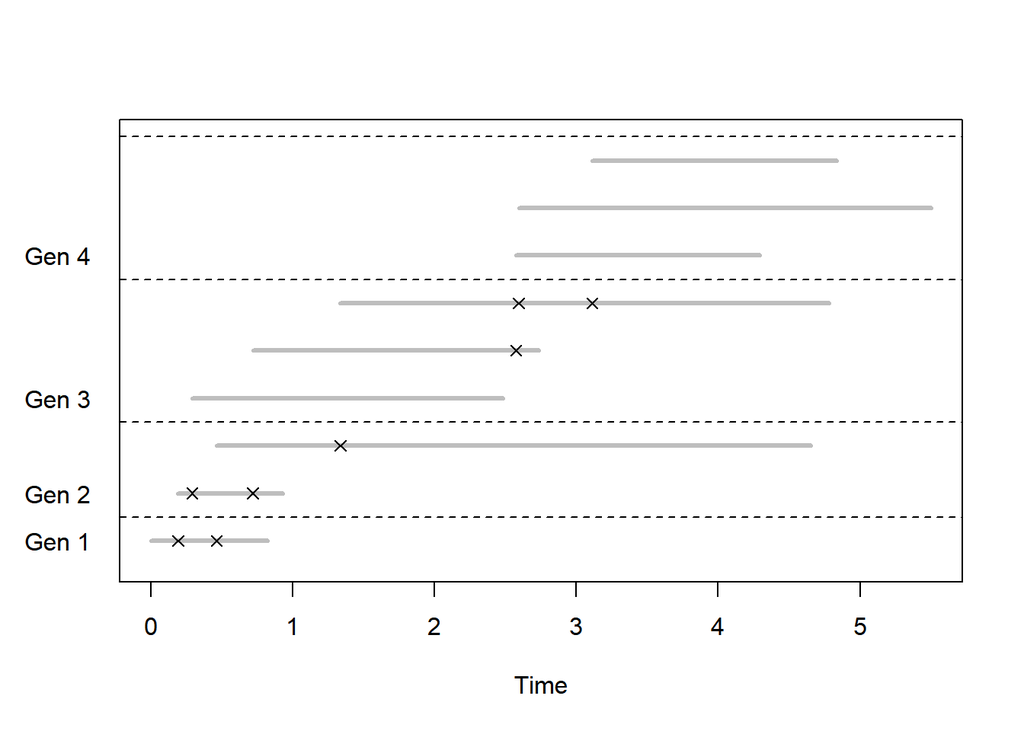

```r
set.seed(seed1)
g = familyTree(lambda = 0.4, kappa = 1, maxGen = 10)

maxLife = max(sapply(g, function(gen) max(gen$completes)))
numFamily = sum(sapply(g, nrow))

plot(0,0, ylim = c(0.5, numFamily + 0.5), xlim = c(0, maxLife),
     xlab = "Time", ylab = "", type ="n",
     axes = FALSE)

box()
axis(1)
numGen = length(g)
numKids = sapply(g, nrow)
treeN = g[ 2:(numGen + 1) ]
birthNum = c(0, cumsum(sapply(g, nrow))[ -length(g)])
axis(2, at = birthNum + 1,
     labels = paste("Gen", 1:numGen), tick = FALSE, las = 1)

mapply(function(gen, nextGen, birthNum) {
  birthOrder = birthNum + (1:nrow(gen))
  segments(x0 = gen$births, x1 = gen$completes, y0 = birthOrder,
          lwd = 3, col = "grey")
  abline(h = 0.5 + max(birthOrder), lty = 2, col="black" )
  if (all(!is.na(nextGen$births)))
  points(x = nextGen$births, y = birthOrder[nextGen$parentID],
         pch = 4)
  },
  gen = g, nextGen = treeN, birthNum = birthNum )
```

###### Figure 1 - Original Family Tree Graph

Figure 1 displays the original custom graph from the Nolan and Lang book. The horizontal gray lines denote the lifetime of a process and the x’s denote the birth of child processes.

In the original graph, it is difficult to tell which parent processes spawned which child processes. This could be valuable information. For instance, it might be observed that the first child born in a generation produces significantly more child process than other processes in its generation. Or it might be observed that the last child process born in a generation never spawns any further child processes. In order to make this more clear, we will color code the lines by parentID. All processes that were spawned by the same parent process will be the same color. Since the first generation does not have a parent process, this line will remain gray.

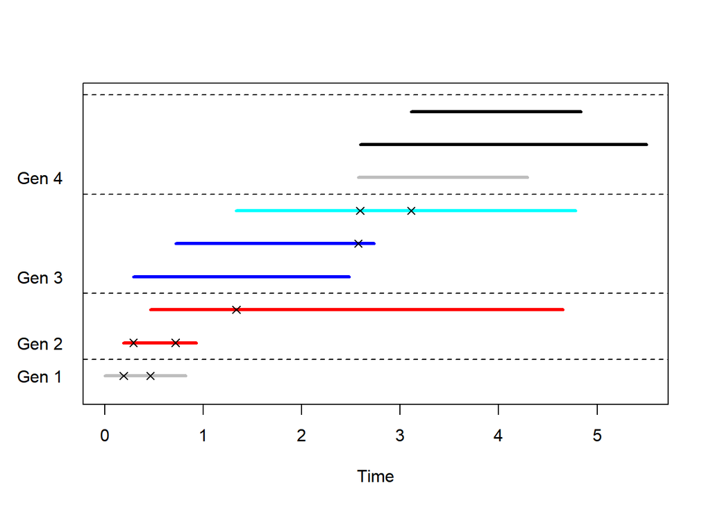

```r
plot(0,0, ylim = c(0.5, numFamily + 0.5), xlim = c(0, maxLife),
     xlab = "Time", ylab = "", type ="n",
     axes = FALSE)

box()
axis(1)
numGen = length(g)
numKids = sapply(g, nrow)
treeN = g[ 2:(numGen + 1) ]
birthNum = c(0, cumsum(sapply(g, nrow))[ -length(g)])
axis(2, at = birthNum + 1,
     labels = paste("Gen", 1:numGen), tick = FALSE, las = 1)

mapply(function(gen, nextGen, birthNum) {
  birthOrder = birthNum + (1:nrow(gen))
  if (nrow(gen) == 1){
    segments(x0 = gen$births, x1 = gen$completes, y0 = birthOrder,
            lwd = 3, col = "grey")
  }
  else {
    segments(x0 = gen$births, x1 = gen$completes, y0 = birthOrder,
            lwd = 3, col = birthOrder[gen$parentID])
  }
  abline(h = 0.5 + max(birthOrder), lty = 2, col="black" )
  if (all(!is.na(nextGen$births)))
  points(x = nextGen$births, y = birthOrder[nextGen$parentID],
         pch = 4)
  },
  gen = g, nextGen = treeN, birthNum = birthNum )
```

###### Figure 2 - Family tree graph color coded by Parent ID

In the new modified graph displayed in Figure 2, each process within a generation is color-coded by its parent process ID. This is especially helpful in generation 4, as two processes were spawned at nearly the same time. Now it is apparent that the first process in generation 4 was spawned by the second process in generation 3 while the second and third processes in generation 4 were spawned by the third process in generation 3.

# Conclusions and Future Work

Visualizations can greatly improve the ability to analyze random branching processes (as well as many other types of procedures). The original custom graph from the Nolan and Lang book goes a long way in enhancing the ability to examine the data produced by the familyTree function. However, it is difficult to distinguish which child processes were spawned by which parent processes. We can see in the modified version of the graph that colorizing a visualization can provide further insight into the data. In this specific example, the added color allows the reader to easily distinguish which child processes were spawned by which parent processes.

There is ample room for future work with this case study. Different formats such as a traditional dendrogram might reveal even more information that can’t be seen in the current graph format. It may also be fruitful to dive deeper into color theory and assign colors in a more purposeful manner. For example, descendants from the same lineage might use colors from the same family through different generations. The graph in this case study is useful for looking at a single family tree, but futher analysis might entail creating hundreds or thousands of family trees that would require a more aggregate analysis. Different variables and a different format would be more appropriate for visualizing that information.

# References

- Lang, D. T., & Nolan, D. A. (2015). Data Science in R: A Case Studies Approach to Computational Reasoning and Problem Solving. CRC Press.